# Bayesian posteriors for the Cabrera link categories

Overview, results and conclusions for discussion

Kesem Abramov

08 September 2026

> Every candidate link at Cabrera carries eight posterior probabilities, one per link category, instead of a single hard label. Four of the eight categories behave the way they claim to when tested against camera records the posterior never saw. Replication saturates after three replicates, so what uncertainty remains is not something more sites can fix.

| Quantity | Value |
| --- | --- |
| Candidate links, six sites | 1,624 |
| Inside the camera grid | 951 (59%) |
| Camera records among them | 262 |
| Prior and model settings compared | 4 |
| Categories confirmed against cameras in all four settings | 4 of 8 |
| Ceiling on confidence for a link not seen locally | 0.533 |

# Overview

## Motivation

The framework sorts every candidate link into one of eight categories using three yes/no facts: does the model predict it, was it seen at this site, was it seen at another site in the same system. Three bits, eight boxes.

The weakness is that the answer is a **label**. A link that only just qualified looks identical to one that clearly belongs, and the label says nothing about which links to chase or what would settle the question.

The posterior replaces the label with a probability spread across all eight categories. It says how much of a link’s evidence really supports its assigned category, which alternative the doubt points toward, and what the cheapest way to raise confidence would be.

## What the pipeline does

1. **Estimates the error rates** from the data itself.
2. **Calibrates the raw model scores** so they read as probabilities, and checks that the hard categorisation is unchanged.
3. **Builds one posterior function** holding every ingredient from the SI.
4. **Checks that function against the SI’s published worked values.**
5. **Runs it under four settings** of prior and model handling.
6. **Produces** category maps, category distributions, a test against camera records, and an evidence-accumulation curve.

**Methodological decisions.** The posterior is one function, and each setting below is an argument to it rather than a separate implementation, so the equation in the manuscript and the code cannot drift apart. Calibration is Platt scaling fitted **site-blocked**, so no site calibrates itself. Platt is monotone and therefore cannot reorder links, which we verify rather than assert: the hard predictions survive intact and only the number on the threshold moves.

## The rates

| Rate | Meaning | Value |
| --- | --- | --- |
| $\epsilon_Y$ | model error, 1 - balanced accuracy | 0.276 |
| $\epsilon_l$ | chance direct observation misses a link that is present | 0.340 |
| $f$ | chance a record is spurious | 0.05 |
| $p_1$ | chance a replicate site records a link that is present | 0.321 |
| $\nu$ | how variable that chance is between links | 2.53 |

**Methodological decisions.** $f$ is the one rate nothing in the data identifies, because the usual negative control (pairs that never co-occur) is excluded from the candidate set by construction. It is fixed a priori and swept in a sensitivity check rather than fitted.

$\epsilon_l$ comes from the camera contrast: both methods watch the same site at the same time, so the difference between them is detection alone. We condition on the links the **cameras** recorded, which makes the estimate directional, as “chance of missing something present” requires. That is the Lincoln-Petersen two-sample estimator. A symmetric alternative gives the wrong answer: Jaccard between the two methods is 0.45, and $1-J$ = 0.55 because it also charges direct observation for links the *cameras* missed.

$p_1$ and $\nu$ are fitted with a zero-truncated likelihood, because we only see pairs recorded at least once, and ignoring that truncation would bias $p_1$ upward.

**Open question.** $\nu$ = 2.53 sits outside the range the SI illustrates and implies a beta shape parameter below 1. Widen the SI wording, or constrain the fit? Separately, 342 links (21%) sit at the floor of the prediction pipeline’s sigmoid and carry no model information to calibrate.

## The four settings

|  | uniform prior | degree-based prior |
| --- | --- | --- |
| **A** model enters through the posterior as $\delta$ | A-uniform | A-degree |
| **B** calibrated model score enters as the prior | B-uniform | B-degree |

Degree priors are global and replicate-based, so a link between two well-connected species starts with more prior weight on the present-side categories.

**Methodological decision.** Four settings rather than one, because the prior is the most arguable choice in the whole construction. Showing that a conclusion holds in all four is stronger than defending any single prior.

# The starting point

The deterministic assignment at the richest site. Each cell is one candidate link, coloured by its single assigned category.

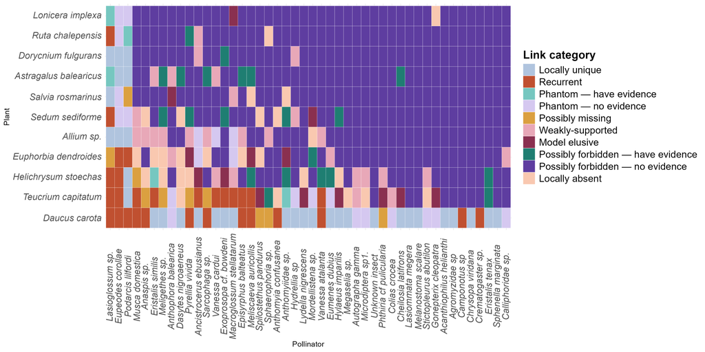

This is the reference the posterior is compared against. It is complete and unambiguous, and that is the problem: nothing in it separates a link the evidence strongly supports from one that only just fell on that side of a boundary.

**Takeaway.** The deterministic map is a reference, not a truth. Anything the posterior does differently has to be judged against independent evidence, not against this figure.

# Results

Categories appear in taxonomy order: the predicted classes first, then the unpredicted class that dominates the candidate set.

In every map below, **colour intensity is the posterior** for that category, a **black frame** marks cells the deterministic rule assigned to it, and an **asterisk** marks a link the cameras recorded. All four panels of a figure share one colour scale, so shades are comparable between settings.

## Possibly missing

Predicted, recorded at other sites, not recorded here. The framework’s highest-priority category, and the one where the prescribed action is simply more effort with the same method.

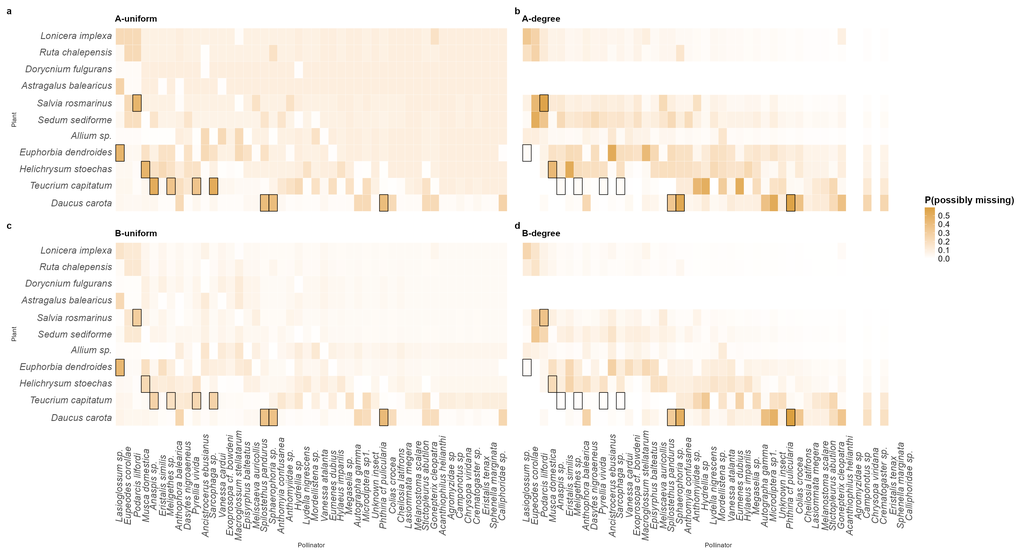

A-uniform is the counterpart of the deterministic assignment and B-uniform looks much like it. The degree-based priors visibly change the picture.

| Setting | Links | Mean posterior on the assigned category | Most likely category is the assigned one |
| --- | --- | --- | --- |
| A-uniform | 51 | 0.448 | 100% |
| A-degree | 51 | 0.300 | 47% |
| B-uniform | 51 | 0.330 | 49% |
| B-degree | 51 | 0.229 | 20% |

**Methodological decision.** Frames come from the deterministic rule and are identical in all four panels, so any difference between panels is the prior talking and nothing else.

**Takeaway.** The label and the confidence are different quantities. A link can sit in possibly missing under the hard rule while the posterior puts most of its weight elsewhere. That is not a bug: the hard rule reads three bits as if they were certain, and the posterior does not.

## Possibly forbidden

Neither predicted nor recorded anywhere: 941 of 1,624 links, by far the largest category.

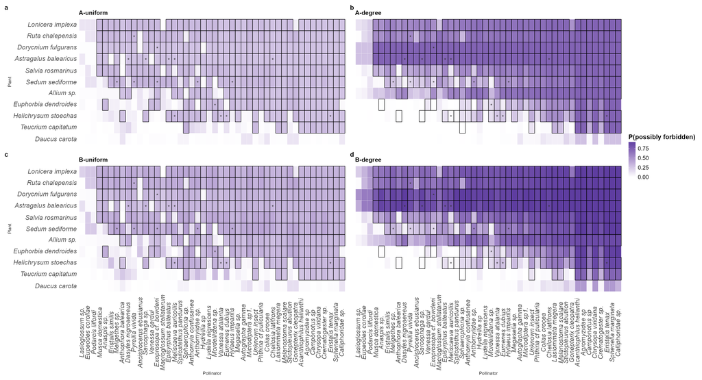

**Discuss** Which model to use?

## Phantom

Predicted, but recorded nowhere. Genuinely ambiguous: either the model is wrong, and an independent method finds nothing, or the interaction is invisible to the method in use, and it does. The two readings predict opposite outcomes, which is why the prescribed action is a different method rather than more effort.

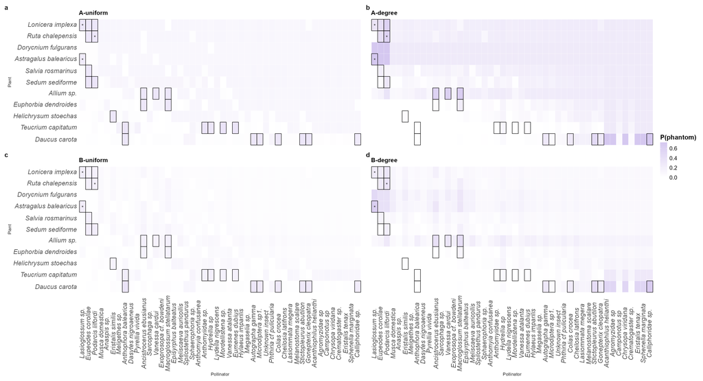

**Takeaway.** Phantom is the one category with no predicted direction, so the camera test below cannot confirm or refute it. The framework says as much already, and the data does not contradict it.

## Where the posterior weight goes

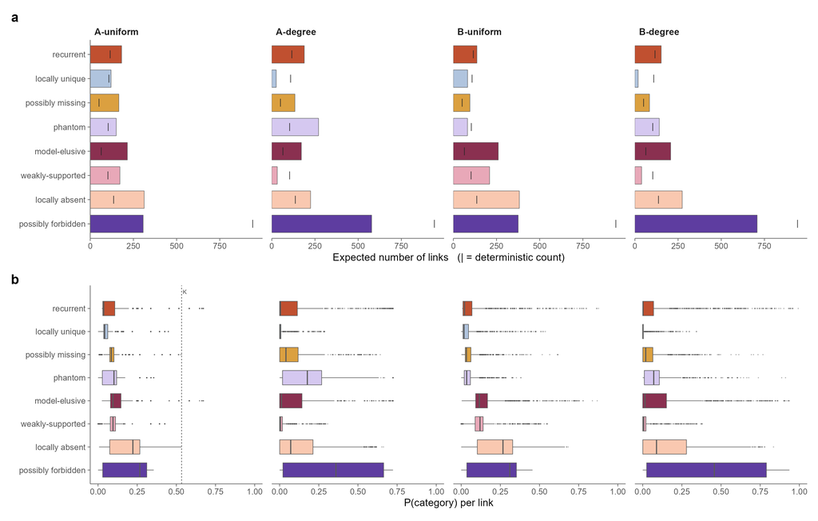

Panel **a** is the expected number of links per category, panel **b** the spread of per-link posteriors. The tick in panel a is the deterministic count, the same in all four panels, so the gap between tick and bar is exactly what each prior moves.

| Setting | Mean posterior on the assigned label | Most likely category is the assigned one | Total gap from the deterministic counts |
| --- | --- | --- | --- |
| A-uniform | 0.354 | 64% | 1269 |
| A-degree | 0.467 | 71% | 1035 |
| B-uniform | 0.383 | 57% | 1229 |
| B-degree | 0.526 | 66% | 776 |

**Methodological decision.** Once a label becomes a distribution, the honest headline number for a category is the **sum of its posterior column**, not a count of links. That is what panel a plots. The dashed line in panel b is $\kappa$ = 0.533, the ceiling for a link not recorded locally under a uniform prior; it is drawn only in the A-uniform panel because the other three relax one of its two conditions.

**Takeaway.** Resembling the deterministic counts is not evidence of being right, because those counts are not truth. The next section supplies a criterion external to both.

## Does confidence buy anything?

The question the whole exercise turns on: if we chase the links the posterior is confident about, do we find more? For possibly forbidden the prediction runs the other way, so the test is whether cameras find **fewer** records among links with a high forbidden posterior.

**Methodological decisions.** This is the measurement to scrutinise, so it is worth being explicit about each choice.

*Independent evidence.* Cameras ran in parallel with direct observation and the posterior never saw them, so they are a fourth source of evidence rather than a restatement of the three the posterior uses.

*Who is in the test.* A link is inside the **camera grid** when both partners appear in that site’s camera data. A zero then means the cameras saw both species there but never together, which is a real negative. Links outside the grid are dropped, since they can neither confirm nor refute.

*How agreement is measured.* One logistic regression per category per setting, predicting whether the cameras recorded a link from that category’s posterior. The effect is reported as an odds ratio per one standard deviation of the posterior, so categories with different spreads stay comparable.

*The adjustment that makes it a real test.* The direct observation is held fixed. Categories are defined partly by that observation, so without this the posterior would largely be re-describing it. Holding it fixed asks: among links whose direct observation was the same, does the posterior still say which ones the cameras find? A second model also adjusts for site, since camera coverage runs from 41% to 82% across sites.

*The expected direction* is set from what each category **claims ecologically**, not from its observation bit. These differ. Possibly missing carries “not seen here”, yet its whole claim is that the interaction is present and was missed, so cameras should find it *more* often.

| Category | Expect | n | Camera-confirmed | % | A-uniform | A-degree | B-uniform | B-degree | Verdict | Site-adjusted | Camera chance, mean -> +1 SD |
| --- | --- | --- | --- | --- | --- | --- | --- | --- | --- | --- | --- |
| recurrent | higher | 100 | 73 | 73 | 1.88*** | 1.41*** | 1.75*** | 1.42*** | supported in 4/4 | holds | 25-26 -> 32-38 |
| locally unique | higher | 77 | 45 | 58 | 0.89 | 0.91 | 0.94 | 0.96 | no signal (0/4) | NA | – |
| possibly missing | higher | 34 | 13 | 38 | 1.60*** | 1.43*** | 1.57*** | 1.39*** | supported in 4/4 | holds | 28-29 -> 33-35 |
| phantom | unclear | 74 | 11 | 15 | 0.83 | 0.82* | 1.06 | 0.93 | no direction predicted (1/4 signal) | NA | 27 -> 24 |
| model-elusive | higher | 54 | 28 | 52 | 0.93 | 1.05 | 0.92 | 1.04 | no signal (0/4) | NA | – |
| weakly-supported | lower | 66 | 27 | 41 | 0.67*** | 0.77*** | 0.69*** | 0.77*** | supported in 4/4 | holds | 28 -> 23-24 |
| locally absent | lower | 94 | 20 | 21 | 1.09 | 1.34** | 1.13 | 1.37** | CONTRADICTED in 2/4 | holds | 28 -> 32-33 |
| possibly forbidden | lower | 452 | 45 | 10 | 0.55*** | 0.61*** | 0.50*** | 0.61*** | supported in 4/4 | holds | 24-26 -> 14-18 |

Reading the table: the four setting columns are odds ratios per one standard deviation of that category’s posterior, with the direct observation held fixed. Above 1, a higher posterior goes with more camera records. Stars are `***` $p<0.001$, `**` $p<0.01$, `*` $p<0.05$. The last column translates the same effect onto the probability scale, which is the figure to quote in prose.

`n` counts links of that category **inside the camera grid**, not the whole category: possibly forbidden has 941 links in total and 452 here.

Four categories are supported in all four settings, and all four survive the site adjustment:

- **recurrent** and **possibly missing** go the right way upward. Possibly missing is the one that matters, because its claim is that the interaction is present and direct observation missed it.
- **weakly-supported** and **possibly forbidden** go the right way downward. For possibly forbidden, one standard deviation up the posterior takes the chance of a camera record from about 25% to about 16%.

**Takeaway.** The posterior is not merely re-describing the observations. Holding the direct observation fixed, it still orders links by how likely an independent method is to find them, in the direction each category claims. That is the operational value of the confidence layer: it turns a category into a ranked list. And with 941 possibly-forbidden links, separating a 25% chance from a 16% chance is what makes the category actionable at all.

**Takeaway.** Sharper is not better. The degree settings concentrate more weight on the assigned label and sit closer to the deterministic counts, and they are the worse calibrated of the four against the camera data: calibration slope 0.64 against 1.34 for the uniform settings, and Brier skill 0.11 against 0.20.

**Open questions.**

- The deck calls B-degree “the most informed model”. It uses the most inputs, but the calibration numbers just quoted say it is the worst of the four. The accurate phrasing is *uses the most inputs*.
- **Locally absent contradicts its expected direction** in the two degree settings. Its claim is that the link is feasible in the system but not realised here, so cameras should find it less often, and under degree priors they find it more. This needs an explanation before it reaches the manuscript.
- $\epsilon_l$ is fitted on the same camera records this test uses. Holding the direct observation fixed limits the exposure, since $\epsilon_l$ enters through the local axis, but a leave-one-site-out refit would remove what remains.

## How much is replication worth here?

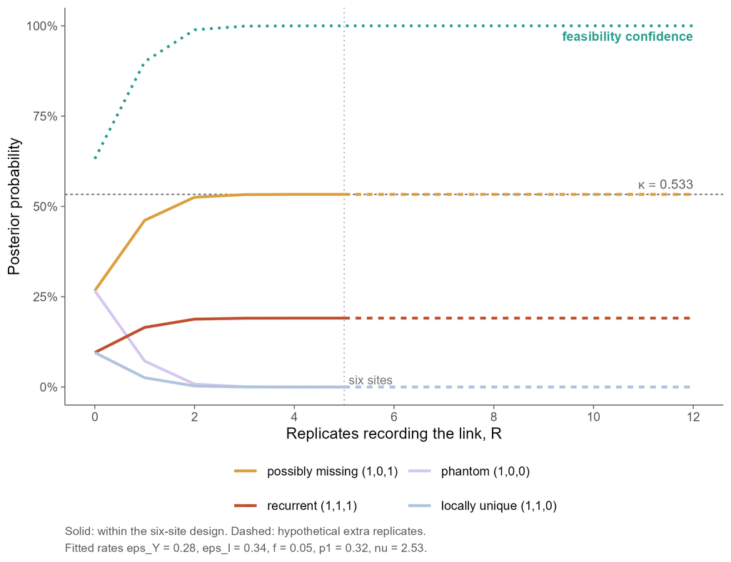

Figure 3a of the manuscript, driven by the rates fitted here rather than illustrative ones. Solid within the six-site design, dashed for hypothetical extra sites.

**Methodological decision.** The curve comes from the same posterior function as everything above, swept over the number of replicates, so this figure and the analysis cannot drift apart. The evidence swept is the possibly-missing signature: predicted, not seen here, detected in every replicate that could have found it.

With $p_1$ = 0.32 against $f$ = 0.05, each replicate is strong evidence, and the posterior reaches $\kappa$ by the third replicate and never moves again.

**Takeaway.** Two or three replicates exhaust what replication can buy here. $\kappa$ = 0.533 follows from the error rates by algebra: it is a structural ceiling, not a measurement, and no amount of sampling passes it. The way past it is a better model or a better local method, which is exactly the corroboration action the framework already prescribes for the categories sitting against it. That is an argument for the framework, not a limitation of it.